# IMMUNE DECONVOLUTION

Christophe Desterke

10/29/2020

## This tutorial explain immune-deconvolution process for a transcriptome dataset

Immune deconvolution of transcriptome is a bioinformatics pipeline which integrate the transcriptome dataset from an organ with the transcriptome of sorted immune cell subpopulations. This procedure helps explain the level of immune infiltration of an organ. This original procedure have been employed in the following publication https://pubmed.ncbi.nlm.nih.gov/33015591/

In this procedure, the COVID19 patient lung dataset (GSE147507) is used along with the data from immune subpopulations included in the dataset (GSE76340).

references of the datasets:

- Blanco-Melo D, Nilsson-Payant BE, Liu WC, Uhl S et al. Imbalanced Host Response to SARS-CoV-2 Drives Development of COVID-19. Cell 2020 May 28;181(5):1036-1045.e9. PMID: 32416070
- Pont MJ, Honders MW, Kremer AN, van Kooten C et al. Microarray Gene Expression Analysis to Evaluate Cell Type Specific Expression of Targets Relevant for Immunotherapy of Hematological Malignancies. PLoS One 2016;11(5):e0155165. PMID: 27171398

### First step is to correct cross batch effect between datasets

In order to correct batch effect in transcriptome SVA bioconductor package will be used. To perform this normalization step, two files are necessary: a file comprising the transcriptome data matrix of the two datasets (this matrix file is named covidcross2.txt) and a metadata file comprising in particular the information of the batches and incidentally data corresponding to biological groups (this file is named metadata.txt).

These pre-process data could be download at the address: https://github.com/cdesterke/covid19sc/tree/master/immunedeconvolution_data

Loading library and data

```r
library(sva)
set<-read.table("covidcross2.txt",h=T)
meta<-read.table("metadata.txt",h=T,sep="\t",row.names = 1)
```

data exploration

```r
knitr::kable(head(meta))
```

|  | batch | id | group |
| --- | --- | --- | --- |
| GSM1981670 | 2 | GSM1981670 | Chronic lymphoblastic leukemia cells |
| GSM1981671 | 2 | GSM1981671 | Chronic lymphoblastic leukemia cells |
| GSM1981672 | 2 | GSM1981672 | Chronic lymphoblastic leukemia cells |
| GSM1981673 | 2 | GSM1981673 | Multiple myeloma cells |
| GSM1981674 | 2 | GSM1981674 | Small intestine epithelial cells |
| GSM1981675 | 2 | GSM1981675 | Colon epithelial cells |

```r
colnames(set)
```

```
##  [1] "GSM1981670"                   "GSM1981671"
##  [3] "GSM1981672"                   "GSM1981673"
##  [5] "GSM1981674"                   "GSM1981675"
##  [7] "GSM1981676"                   "GSM1981677"
##  [9] "GSM1981678"                   "GSM1981679"
## [11] "GSM1981680"                   "GSM1981681"
## [13] "GSM1981682"                   "GSM1981683"
## [15] "GSM1981684"                   "GSM1981685"
## [17] "GSM1981686"                   "GSM1981687"
## [19] "GSM1981688"                   "GSM1981689"
## [21] "GSM1981690"                   "GSM1981691"
## [23] "GSM1981692"                   "GSM1981693"
## [25] "GSM1981694"                   "GSM1981695"
## [27] "GSM1981696"                   "GSM1981697"
## [29] "GSM1981698"                   "GSM1981699"
```

[output cut: 22 more lines]

## SVA batch correction

```
## Found 300 genes with uniform expression within a single batch (all zeros); these will not be adjusted for batch.
```

```
## Found2batches
```

```
## Adjusting for0covariate(s) or covariate level(s)
```

```
## Standardizing Data across genes
```

```
## Fitting L/S model and finding priors
```

```
## Finding parametric adjustments
```

```
## Adjusting the Data
```

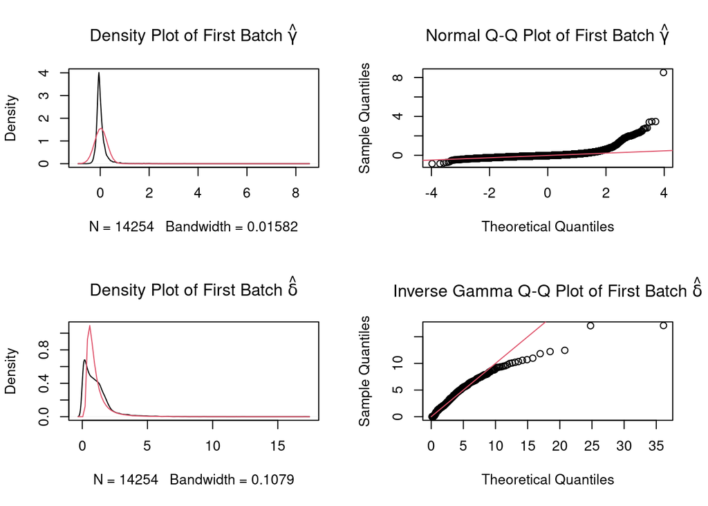

```r
batch=meta$batch
modcombat=model.matrix(~1,data=meta)
mat<-as.matrix(set)
edata<-ComBat(dat=mat,batch=batch,mod=modcombat,par.prior=TRUE, prior.plots = TRUE)
```

Reduction of the corrected matrix to the genelist found to be differentially expressed between healthy donors and COVID19 lungs. This gene list is nammed deg.txt and could be downloaded at the following address:

https://github.com/cdesterke/covid19sc/tree/master/immunedeconvolution_data

Data pre-processing for principal component analysis

```r
deg<-read.table("deg.txt",h=T)
head(deg)
```

```
##          gene  logFC AveExpr       t PValue adjPVal      B
## IFI6     IFI6 7.1776 13.6855 62.6608  0e+00  0.0416 2.8234
## DAPP1   DAPP1 5.3198  9.5271 40.7539  1e-04  0.0416 2.4574
## MX1       MX1 4.8482 12.2353 38.6539  1e-04  0.0416 2.3942
## CLEC4E CLEC4E 7.4028 11.3749 37.9561  1e-04  0.0416 2.3713
## CASP5   CASP5 5.0590  8.6360 37.1177  1e-04  0.0416 2.3426
## FFAR2   FFAR2 6.4971 10.1686 35.2980  1e-04  0.0416 2.2748
```

```r
small<-merge(deg,edata,by="row.names")
dim(small)
```

```
## [1] 95 81
```

```r
colnames(small)
```

```
##  [1] "Row.names"                    "gene"
##  [3] "logFC"                        "AveExpr"
##  [5] "t"                            "PValue"
##  [7] "adjPVal"                      "B"
##  [9] "GSM1981670"                   "GSM1981671"
## [11] "GSM1981672"                   "GSM1981673"
## [13] "GSM1981674"                   "GSM1981675"
## [15] "GSM1981676"                   "GSM1981677"
## [17] "GSM1981678"                   "GSM1981679"
## [19] "GSM1981680"                   "GSM1981681"
## [21] "GSM1981682"                   "GSM1981683"
## [23] "GSM1981684"                   "GSM1981685"
## [25] "GSM1981686"                   "GSM1981687"
## [27] "GSM1981688"                   "GSM1981689"
## [29] "GSM1981690"                   "GSM1981691"
```

[output cut: 26 more lines]

```r
row.names(small)<-small$Row.names
ok<-small[,9:ncol(small)]
trans<-t(ok)
data<-data.frame(trans,meta$group)
library(dplyr)
sub<-filter(data,meta.group == "COVID19_lung" | meta.group == "HD_lung" | meta.group == "Fibroblasts" | meta.group == "Type I macrophages" | meta.group == "Primary bronchial epithelial cells" | meta.group == "Type 2 macrophages" | meta.group == "B-cells")
```

## Unsupervized principal component analysis

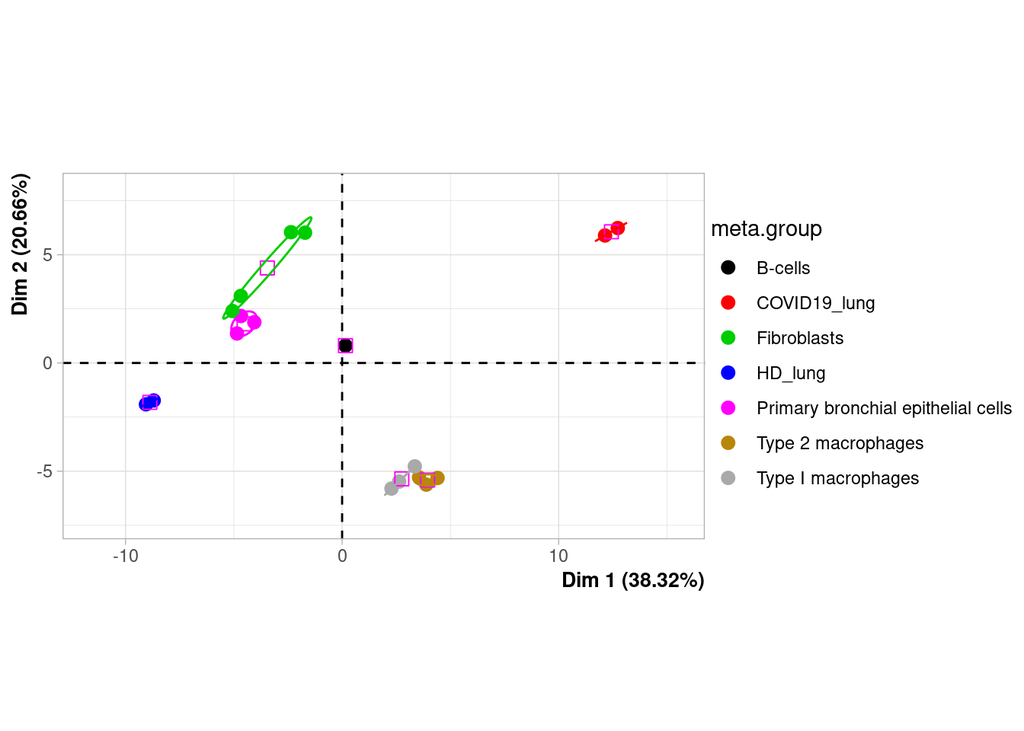

```r
library(FactoMineR)
res = PCA(sub, scale.unit=TRUE, ncp=5, quali.sup=96, graph=F)
plotellipses(res,label="none",title="", cex=2)
```

```r
# description of the first principal axis which discriminated healthy donor and COVID19 lungs
output<-dimdesc(res)
output$Dim.1
```

```
## $quanti
##          correlation      p.value
## CXORF21    0.9513887 1.345518e-09
## TNFSF8     0.9214447 5.686636e-08
## RNASE2     0.9131802 1.232664e-07
## CASP5      0.8987277 4.031911e-07
## METTL7B    0.8974261 4.446782e-07
## GAPT       0.8884915 8.425405e-07
## P2RY13     0.8874100 9.069726e-07
## DAPP1      0.8567931 5.619023e-06
## CD38       0.8369665 1.484547e-05
## RGL4       0.8296138 2.061562e-05
## CCL11      0.8260742 2.401548e-05
## TRIM38     0.8256055 2.449965e-05
## NFKBID     0.8205657 3.025538e-05
## ZBP1       0.8151475 3.769254e-05
## CLEC4E     0.8029324 6.035080e-05
## WIPF1      0.8027472 6.076791e-05
## LILRA6     0.8021862 6.204656e-05
## FAM49A     0.7842543 1.168835e-04
## SELL       0.7840584 1.176567e-04
## HP         0.7794299 1.372263e-04
## PLEK       0.7622759 2.355588e-04
## WAS        0.7542776 2.986016e-04
## PTK2B      0.7540073 3.009590e-04
## SP140      0.7526967 3.126086e-04
## HESX1      0.7517720 3.210551e-04
## TREM1      0.7496070 3.415839e-04
## CACNA1A    0.7360110 4.973967e-04
## TRIM21     0.7289751 5.990062e-04
## SERPINA1   0.7208752 7.369426e-04
## RAC2       0.7181270 7.893803e-04
## HPGDS      0.7141008 8.718035e-04
## BCL2A1     0.7134118 8.866026e-04
## MXD1       0.7131843 8.915350e-04
## NBN        0.7115910 9.267219e-04
## DOK3       0.7004652 1.206155e-03
## CISD2      0.6960145 1.335985e-03
## CCL7       0.6953005 1.357852e-03
## LGALS9     0.6950473 1.365680e-03
```

[output cut: 22 more lines]

```
## PFN1       0.5311504 2.331660e-02
## ZC3HAV1    0.5253698 2.515542e-02
## SERF2      0.4831034 4.226417e-02
##
## $quali
##                   R2      p.value
## meta.group 0.9849299 2.266908e-09
##
## $category
##                         Estimate      p.value
## meta.group=COVID19_lung 12.08458 0.0006060342
## meta.group=HD_lung      -9.22564 0.0269064683
##
## attr(,"class")
## [1] "condes" "list "
```